# Case Study 1

Zoheb Allam

October 31, 2016

# R Code for Case Study 1

## Introduction

The following analyses were conducted to determine the relationship between GDP and income group. Gross domestic product (GDP) can be definised as the value of all the finished goods and services producted within a country’s borders. Prior studies have examined the relationship between GDP and income and this study adds to the exisiting pool of knowledge.

## Methods

The data used for this study was collected by the world bank and included information on over 200 countries. In order to test the relationships between GDP and income group, the data from the two seperate data files containing GDP and income group were merged and the relationships were tested using descriptive statistics as well as graphically plotting the relationship.The next section contains the code used to clean and analyze the data as well as an explanation of the findings.

## Results

Results from this study are presented as answers to a series of questions designed to explore the data.

In order to run the code, set the working directory. My source codes were stored in the file path below.

```r
setwd("C:/Users/laptop/Desktop/Case Study 1/Analyses")
```

To download the data into R, run the following code.

```r
source("DownloadData.R", echo = TRUE, keep.source = TRUE, max.deparse.length = 500)
```

```
##
## > #download the data into R
## > EducData <- read.csv("EducationalData.csv", header=T, na.strings=c("","NA"))
##
## > GDPData <- read.csv("GDPData.csv",header=T, na.strings=c("","NA"))
```

To answer Question 1 of the case study I merged the data on the country shortcode. The code below merged the data and the string function was used to determine how many of the IDs match. In total 224 observations matched after dropping countries that did not match from the merged data file.

```r
source("MergeData.R", echo = TRUE, keep.source = TRUE, max.deparse.length = 500)
```

```
##
## > ##Question 1
## > #Merge the data
## > MergedData <- merge(x = EducData, y = GDPData, by = "CountryCode", all = FALSE)
##
## > str(MergedData)
## 'data.frame':    224 obs. of  34 variables:
##  $ CountryCode                                      : Factor w/ 234 levels "ABW","ADO","AFG",..: 1 2 3 4 5 6 7 8 9 10 ...
##  $ Long.Name                                        : Factor w/ 234 levels "American Samoa",..: 5 104 57 99 108 226 4 109 1 2 ...
##  $ Income.Group                                     : Factor w/ 5 levels "High income: nonOECD",..: 1 1 3 4 5 1 5 4 5 5 ...
##  $ Region                                           : Factor w/ 7 levels "East Asia & Pacific",..: 3 2 6 7 2 4 3 2 1 3 ...
##  $ Lending.category                                 : Factor w/ 3 levels "Blend","IBRD",..: NA NA 3 3 2 NA 2 1 NA 2 ...
##  $ Other.groups                                     : Factor w/ 2 levels "Euro area","HIPC": NA NA 2 NA NA NA NA NA NA NA ...
##  $ Currency.Unit                                    : Factor w/ 154 levels "Afghan afghani",..: 7 48 1 4 2 143 5 6 144 43 ...
##  $ Latest.population.census                         : Factor w/ 27 levels "1970","1979",..: 16 27 2 1 17 21 17 17 16 17 ...
```

[output cut: 26 more lines]

Once the data was merged, there was a few data cleaning steps that needed to take place. I counted the number of missing data points (N/A) in the data file, converted GDP into a numeric value, and log transformed it due to the skewed distribution.

```r
source("CleanData.R", echo = TRUE, keep.source = TRUE, max.deparse.length = 500)
```

```
##
## > #Count the number of missing for variables of interest#
## > sum(is.na(MergedData$Income.Group))
## [1] 14
##
## > sum(is.na(MergedData$Ranking))
## [1] 35
##
## > sum(is.na(MergedData$GDP))
## [1] 21
##
## > #convert GDP into numeric
## > MergedData$GDP.N <- as.numeric(gsub("[^[:digit:]]","", MergedData$GDP))
##
## > #Log transformed GDP due to skewed distribution
## > MergedData$GDP.N.log <- log(MergedData$GDP.N)
```

To answer Question 2 I sorted the data frame by rankings and checked the rank of the country which appeared 13th on the list. However, there were two countries with the same rank (178). Since they had the same GDP and there were no other variables in the data file which could distinguish between the ranks, the 13th country in the data file could either be Grenada or St. Kitts and Nevis. The name of the country associated with that rank was called using the grep function.

```r
source("Question2Code.R", echo = TRUE, keep.source = TRUE, max.deparse.length = 500)
```

```
##
## > ##Question 2
## > MergedData$Ranking[order(MergedData$Ranking, decreasing = TRUE)]
##   [1] 190 189 188 187 186 185 184 183 182 181 180 178 178 177 176 175 174
##  [18] 173 172 171 170 169 168 167 166 165 164 163 162 161 160 159 158 157
##  [35] 156 155 154 153 152 151 150 149 148 147 146 145 144 143 142 141 140
##  [52] 139 138 137 136 135 134 133 132 130 129 128 127 126 125 124 123 122
##  [69] 121 120 119 118 117 116 115 114 113 112 111 110 109 108 107 106 105
##  [86] 104 103 102 101 100  99  98  97  96  95  94  93  92  91  90  89  88
## [103]  87  86  85  84  83  82  81  80  79  78  77  76  75  74  73  72  71
## [120]  70  69  68  67  66  65  64  63  62  61  60  59  58  57  56  55  54
## [137]  53  52  51  50  49  48  47  46  45  44  43  42  41  40  39  38  37
## [154]  36  35  34  33  32  31  30  29  28  27  26  25  24  23  22  21  20
## [171]  19  18  17  16  15  14  13  12  11  10   9   8   7   6   5   4   3
## [188]   2   1  NA  NA  NA  NA  NA  NA  NA  NA  NA  NA  NA  NA  NA  NA  NA
## [205]  NA  NA  NA  NA  NA  NA  NA  NA  NA  NA  NA  NA  NA  NA  NA  NA  NA
## [222]  NA  NA  NA
##
## > grep("178", MergedData$Ranking)
## [1]  78 106
##
## > MergedData$Long.Name[78]
## [1] Grenada
## 234 Levels: American Samoa Antigua and Barbuda ... World
##
## > MergedData$Long.Name[106]
## [1] St. Kitts and Nevis
## 234 Levels: American Samoa Antigua and Barbuda ... World
```

A table was created to examine the average GDP rankings for the “High income:OECD” and “High income:nonOECD”. The average GDP ranking for the High income:OECD group is 33, while the average ranking for the High income:nonOECD group is 91.9.

```r
source("Question3Code.R", echo = TRUE, keep.source = TRUE, max.deparse.length = 500)
```

```
##
## > ##Question 3
## > mean <- tapply(MergedData$Ranking,MergedData$Income.Group, mean,  na.rm=TRUE)
##
## > sd <- tapply(MergedData$Ranking,MergedData$Income.Group, sd,  na.rm=TRUE)
##
## > median <- tapply(MergedData$Ranking,MergedData$Income.Group, median,  na.rm=TRUE)
##
## > max <- tapply(MergedData$Ranking,MergedData$Income.Group, max,  na.rm=TRUE)
##
## > cbind(mean, median, sd, max)
##                           mean median       sd max
## High income: nonOECD  91.91304   94.0 42.68799 161
## High income: OECD     32.96667   24.5 27.54868 122
## Low income           133.72973  139.0 29.65135 182
## Lower middle income  107.70370   99.5 54.19136 190
## Upper middle income   92.13333   83.0 56.51010 187
##
## > round(cbind(mean, median, sd, max),digits=1)
##                       mean median   sd max
## High income: nonOECD  91.9   94.0 42.7 161
## High income: OECD     33.0   24.5 27.5 122
## Low income           133.7  139.0 29.7 182
## Lower middle income  107.7   99.5 54.2 190
## Upper middle income   92.1   83.0 56.5 187
```

To visually explore the relationship between the GDP of the countries and the income group, a scatter plot was created using ggplot2. The log transformed GDP was used for easier interpretation of the plot. By examining the plot we can see that countries with low income and lower middle income overall had lower GDP compared to countries with high income. It should also be noted that the dark gray dots indicate countries with missing values for income group.

```r
source("Question4Code.R", echo = TRUE, keep.source = TRUE, max.deparse.length = 500)
```

```
##
## > ##Question 4
## > library (ggplot2)
```

```
##
## > qplot(CountryCode, GDP.N.log, data=MergedData,color=Income.Group,
## +       xlab="Country", ylab="GDP")
```

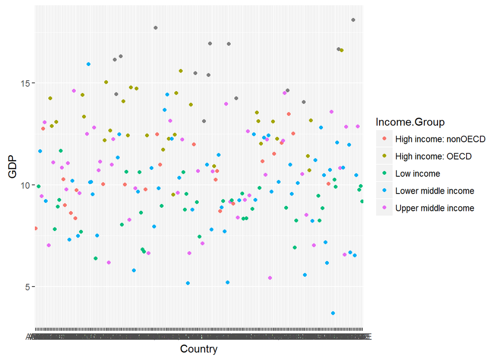

```r
source("Question5Code.R", echo = TRUE, keep.source = TRUE, max.deparse.length = 500)
```

```
##
## > ##Question 5
## > quantile(MergedData$Ranking, prob = seq(0, 1, length = 11), type = 5, na.rm = TRUE)
##    0%   10%   20%   30%   40%   50%   60%   70%   80%   90%  100%
##   1.0  19.4  38.3  57.2  76.1  95.0 113.9 133.8 152.7 171.6 190.0
##
## > MergedData$Ranking.Group[MergedData$Ranking < 38] <- 1
##
## > MergedData$Ranking.Group[MergedData$Ranking == 38] <-2
##
## > MergedData$Ranking.Group[MergedData$Ranking > 38 & MergedData$Ranking <76 ] <-2
##
## > MergedData$Ranking.Group[MergedData$Ranking == 76] <-3
##
## > MergedData$Ranking.Group[MergedData$Ranking > 76 & MergedData$Ranking <113 ] <-3
##
## > MergedData$Ranking.Group[MergedData$Ranking == 113] <-4
##
## > MergedData$Ranking.Group[MergedData$Ranking > 113 & MergedData$Ranking < 152] <-4
##
## > MergedData$Ranking.Group[MergedData$Ranking == 152] <-5
##
## > MergedData$Ranking.Group[MergedData$Ranking > 152] <- 5
##
## > library(gmodels)
```

```
##
## > CrossTable(MergedData$Income.Group, MergedData$Ranking.Group)
##
##
##    Cell Contents
## |-------------------------|
## |                       N |
## | Chi-square contribution |
## |           N / Row Total |
## |           N / Col Total |
## |         N / Table Total |
## |-------------------------|
##
##
## Total Observations in Table:  189
##
##
##                         | MergedData$Ranking.Group
## MergedData$Income.Group |         1 |         2 |         3 |         4 |         5 | Row Total |
## ------------------------|-----------|-----------|-----------|-----------|-----------|-----------|
##    High income: nonOECD |         4 |         5 |         7 |         5 |         2 |        23 |
##                         |     0.056 |     0.031 |     1.385 |     0.031 |     1.589 |           |
##                         |     0.174 |     0.217 |     0.304 |     0.217 |     0.087 |     0.122 |
##                         |     0.108 |     0.132 |     0.189 |     0.132 |     0.051 |           |
##                         |     0.021 |     0.026 |     0.037 |     0.026 |     0.011 |           |
## ------------------------|-----------|-----------|-----------|-----------|-----------|-----------|
##       High income: OECD |        18 |        10 |         1 |         1 |         0 |        30 |
##                         |    25.041 |     2.611 |     4.043 |     4.198 |     6.190 |           |
##                         |     0.600 |     0.333 |     0.033 |     0.033 |     0.000 |     0.159 |
##                         |     0.486 |     0.263 |     0.027 |     0.026 |     0.000 |           |
##                         |     0.095 |     0.053 |     0.005 |     0.005 |     0.000 |           |
## ------------------------|-----------|-----------|-----------|-----------|-----------|-----------|
##              Low income |         0 |         1 |         9 |        15 |        12 |        37 |
##                         |     7.243 |     5.574 |     0.426 |     7.685 |     2.496 |           |
##                         |     0.000 |     0.027 |     0.243 |     0.405 |     0.324 |     0.196 |
##                         |     0.000 |     0.026 |     0.243 |     0.395 |     0.308 |           |
##                         |     0.000 |     0.005 |     0.048 |     0.079 |     0.063 |           |
## ------------------------|-----------|-----------|-----------|-----------|-----------|-----------|
##     Lower middle income |         4 |        14 |        11 |         9 |        16 |        54 |
##                         |     4.085 |     0.910 |     0.017 |     0.318 |     2.117 |           |
##                         |     0.074 |     0.259 |     0.204 |     0.167 |     0.296 |     0.286 |
##                         |     0.108 |     0.368 |     0.297 |     0.237 |     0.410 |           |
##                         |     0.021 |     0.074 |     0.058 |     0.048 |     0.085 |           |
## ------------------------|-----------|-----------|-----------|-----------|-----------|-----------|
##     Upper middle income |        11 |         8 |         9 |         8 |         9 |        45 |
##                         |     0.545 |     0.121 |     0.004 |     0.121 |     0.009 |           |
##                         |     0.244 |     0.178 |     0.200 |     0.178 |     0.200 |     0.238 |
##                         |     0.297 |     0.211 |     0.243 |     0.211 |     0.231 |           |
##                         |     0.058 |     0.042 |     0.048 |     0.042 |     0.048 |           |
## ------------------------|-----------|-----------|-----------|-----------|-----------|-----------|
##            Column Total |        37 |        38 |        37 |        38 |        39 |       189 |
##                         |     0.196 |     0.201 |     0.196 |     0.201 |     0.206 |           |
## ------------------------|-----------|-----------|-----------|-----------|-----------|-----------|
##
##
```